# B24_Hadamard

| Abuzer Yakaryilmaz \| April 04, 2019 (updated) |
| --- |
| This cell contains some macros. If there is a problem with displaying mathematical formulas, please run this cell to load these macros. |

$ \newcommand{\bra}[1]{\langle #1|} $ $ \newcommand{\ket}[1]{|#1\rangle} $ $ \newcommand{\braket}[2]{\langle #1|#2\rangle} $ $ \newcommand{\dot}[2]{ #1 \cdot #2} $ $ \newcommand{\biginner}[2]{\left\langle #1,#2\right\rangle} $ $ \newcommand{\mymatrix}[2]{\left( \begin{array}{#1} #2\end{array} \right)} $ $ \newcommand{\myvector}[1]{\mymatrix{c}{#1}} $ $ \newcommand{\myrvector}[1]{\mymatrix{r}{#1}} $ $ \newcommand{\mypar}[1]{\left( #1 \right)} $ $ \newcommand{\mybigpar}[1]{ \Big( #1 \Big)} $ $ \newcommand{\sqrttwo}{\frac{1}{\sqrt{2}}} $ $ \newcommand{\dsqrttwo}{\dfrac{1}{\sqrt{2}}} $ $ \newcommand{\onehalf}{\frac{1}{2}} $ $ \newcommand{\donehalf}{\dfrac{1}{2}} $ $ \newcommand{\hadamard}{ \mymatrix{rr}{ \sqrttwo & \sqrttwo \\ \sqrttwo & -\sqrttwo }} $ $ \newcommand{\vzero}{\myvector{1\\0}} $ $ \newcommand{\vone}{\myvector{0\\1}} $ $ \newcommand{\vhadamardzero}{\myvector{ \sqrttwo \\ \sqrttwo } } $ $ \newcommand{\vhadamardone}{ \myrvector{ \sqrttwo \\ -\sqrttwo } } $ $ \newcommand{\myarray}[2]{ \begin{array}{#1}#2\end{array}} $ $ \newcommand{\X}{ \mymatrix{cc}{0 & 1 \\ 1 & 0} } $ $ \newcommand{\Z}{ \mymatrix{rr}{1 & 0 \\ 0 & -1} } $ $ \newcommand{\Htwo}{ \mymatrix{rrrr}{ \frac{1}{2} & \frac{1}{2} & \frac{1}{2} & \frac{1}{2} \\ \frac{1}{2} & -\frac{1}{2} & \frac{1}{2} & -\frac{1}{2} \\ \frac{1}{2} & \frac{1}{2} & -\frac{1}{2} & -\frac{1}{2} \\ \frac{1}{2} & -\frac{1}{2} & -\frac{1}{2} & \frac{1}{2} } } $ $ \newcommand{\CNOT}{ \mymatrix{cccc}{1 & 0 & 0 & 0 \\ 0 & 1 & 0 & 0 \\ 0 & 0 & 0 & 1 \\ 0 & 0 & 1 & 0} } $ $ \newcommand{\norm}[1]{ \left\lVert #1 \right\rVert } $

## Hadamard

An operator for quantum coin-flipping is called Hadamard.

It is referred as h-gate in Qiskit.

### The first experiment

Let's implement the first experiment.

Our quantum bit (**qubit**) starts in state 0, which is shown as $ \ket{0} $.

*Note: $ \ket{\cdot} $ is called ket-notation: Ket-notation is used to represent a column vector in quantum mechanics. For a given column vector $ \ket{v} $, its conjugate transpose is a row vector represented as $ \bra{v} $ (bra-notation).*

#### The circuit with a single Hadamard

Let's desing a circuit with one qubit, and apply quantum coin-flipping once.

```python
# import all necessary objects and methods for quantum circuits
from qiskit import QuantumRegister, ClassicalRegister, QuantumCircuit, execute, Aer

# define a quantum register with one qubit
qreg1 =  QuantumRegister(1)

# define a classical register with one bit
# it stores the measurement result of the quantum part
creg1 = ClassicalRegister(1)

# define our quantum circuit
mycircuit1 = QuantumCircuit(qreg1,creg1)

# apply h-gate (Hadamard: quantum coin-flipping) to the first qubit
mycircuit1.h(qreg1[0])

# measure the first qubit, and store the result in the first classical bit
mycircuit1.measure(qreg1,creg1)

print("Everything looks fine, let's continue ...")
```

```
Everything looks fine, let's continue ...
```

```python
# draw the circuit by using ASCII art
mycircuit1.draw()
```

```
         ┌───┐┌─┐
q0_0: |0>┤ H ├┤M├
         └───┘└╥┘
 c0_0: 0 ══════╩═
```

```python
# draw the circuit by using matplotlib

mycircuit1.draw(output='mpl',reverse_bits=True)
# reexecute this cell if you DO NOT see the circuit diagram
```

[figure not shown]

```python
# execute the circuit 10000 times in the local simulator

job = execute(mycircuit1,Aer.get_backend('qasm_simulator'),shots=10000)
counts1 = job.result().get_counts(mycircuit1)
print(counts1) # print the outcomes
```

```
{'0': 4956, '1': 5044}
```

The numbers of outcomes '0's and '1's are expected to be close to each other.

[figure not shown]

**As we have observed after this implementation, quantum systems output probabilistically.**

### The third experiment

Currently, the intermediate measurements are not possible to implement.

Therefore, we skip the second experiment and implement the third experiment.

[figure not shown]

#### The circuit with two Hadamards

We design a circuit with one qubit, and apply quantum coin-flipping twice.

```python
# import all necessary objects and methods for quantum circuits
from qiskit import QuantumRegister, ClassicalRegister, QuantumCircuit, execute, Aer

# define a quantum register with one qubit
qreg2 =  QuantumRegister(1)

# define a classical register with one bit
# it stores the measurement result of the quantum part
creg2 = ClassicalRegister(1)

# define our quantum circuit
mycircuit2 = QuantumCircuit(qreg2,creg2)

# apply h-gate (Hadamard: quantum coin-flipping) to the first qubit
mycircuit2.h(qreg2[0])

# apply h-gate (Hadamard: quantum coin-flipping) to the first qubit once more
mycircuit2.h(qreg2[0])

# measure the first qubit, and store the result in the first classical bit
mycircuit2.measure(qreg2,creg2)

print("Everything looks fine, let's continue ...")
```

```
Everything looks fine, let's continue ...
```

```python
# draw the circuit by using matplotlib

mycircuit2.draw(output='mpl',reverse_bits=True)
# reexecute me if you DO NOT see the circuit diagram
```

[output not shown]

```python
# execute the circuit 10000 times in the local simulator

job = execute(mycircuit2,Aer.get_backend('qasm_simulator'),shots=10000)
counts2 = job.result().get_counts(mycircuit2)
print(counts2)
```

```
{'0': 10000}
```

The only outcome must be '0'.

[figure not shown]

### Task 1

Remember that x-gate flips the value of a qubit.

Design a quantum circuit with a single qubit.

The qubit is initially set to $ \ket{0} $.

Set the value of qubit to $ \ket{1} $ by using x-gate.

Experiment 1: Apply one Hadamard gate, make measurement, and execute your program 10000 times.

Experiment 2: Apply two Hadamard gates, make measurement, and execute your program 10000 times.

Compare your results.

```python
#
# your solution is here
#

# start with 1 do the same experiment
# define a quantum register with one qubit
qreg1 =  QuantumRegister(1)

# define a classical register with one bit
# it stores the measurement result of the quantum part
creg1 = ClassicalRegister(1)

# define our quantum circuit
mycircuit1 = QuantumCircuit(qreg1,creg1)

# reverse the bit
mycircuit1.x(qreg1[0])

# apply h-gate (Hadamard: quantum coin-flipping) to the first qubit
mycircuit1.h(qreg1[0])

# measure the first qubit, and store the result in the first classical bit
mycircuit1.measure(qreg1,creg1)

# get the numbers
job = execute(mycircuit1,Aer.get_backend('qasm_simulator'),shots=10000)
counts1 = job.result().get_counts(mycircuit1)
print(counts1) # print the outcomes
```

```
{'0': 5026, '1': 4974}
```

```python
# draw the circuit by using ASCII art
mycircuit1.draw()
```

```
         ┌───┐┌───┐┌─┐
q2_0: |0>┤ X ├┤ H ├┤M├
         └───┘└───┘└╥┘
 c2_0: 0 ═══════════╩═
```

```python
mycircuit1.draw(output='mpl',reverse_bits=True)
# reexecute this cell if you DO NOT see the circuit diagram
```

[output not shown]

```python
# 2nd experiment with the resersed bit
# define a quantum register with one qubit
qreg2 =  QuantumRegister(1)

# define a classical register with one bit
# it stores the measurement result of the quantum part
creg2 = ClassicalRegister(1)

# define our quantum circuit
mycircuit2 = QuantumCircuit(qreg2,creg2)

# reverse the bit start with 1
mycircuit2.x(qreg2[0])

# apply h-gate (Hadamard: quantum coin-flipping) to the first qubit
mycircuit2.h(qreg2[0])

# apply h-gate (Hadamard: quantum coin-flipping) to the first qubit once more
mycircuit2.h(qreg2[0])

# measure the first qubit, and store the result in the first classical bit
mycircuit2.measure(qreg2,creg2)


job = execute(mycircuit2,Aer.get_backend('qasm_simulator'),shots=10000)
counts2 = job.result().get_counts(mycircuit2)
print(counts2)
```

```
{'1': 10000}
```

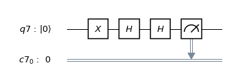

```python
mycircuit2.draw(output='mpl',reverse_bits=True)
# reexecute this cell if you DO NOT see the circuit diagram
```

click for our solution